# COVID-19 affect on Australia?

2023-01-22

```r
covid_data <- read_csv("https://raw.githubusercontent.com/owid/covid-19-data/master/public/data/owid-covid-data.csv")
#summary (covid_data)
```

```r
#unique(covid_data$location)
#unique(covid_data$continent)

empty_covid <- covid_data %>% filter(is.na(continent))
empty_covid

unique(covid_data$continent)
empty_covid2 <- covid_data %>% filter(continent == "" | location == "Africa")
empty_covid2

empty_covid_l <- covid_data %>% filter(location == "Africa")
empty_covid_l

empty_covid_lw <- covid_data %>% filter(location == "World")
empty_covid_lw

empty_covid_c <- covid_data %>% filter(continent == "Africa")
empty_covid_c
```

```r
oc_data <- covid_data %>%
  select('continent', 'location', 'date', 'hosp_patients', 'extreme_poverty','new_deaths', 'total_deaths') %>%
  filter(location == "Oceania"|continent == "Oceania") %>%
  mutate(location = replace(location,location == "Oceania", "Australia"))
```

```r
oc_start <- oc_data[oc_data$date >= "2020-03-01" & oc_data$date <="2022-12-31", ]

#oc_start$hosp_patients[is.na(oc_start$hosp_patients)] <- 0
#oc_start$new_deaths[is.na(oc_start$new_deaths)] <- 0
```

```r
library(ggplot2)
oc_start
```

```
## # A tibble: 18,499 × 7
##    continent location  date       hosp_patients extreme_poverty new_de…¹ total…²
##    <chr>     <chr>     <date>             <dbl>           <dbl>    <dbl>   <dbl>
##  1 Oceania   Australia 2020-03-01             0             0.5        1       1
##  2 Oceania   Australia 2020-03-02             0             0.5        0       1
##  3 Oceania   Australia 2020-03-03             0             0.5        0       1
##  4 Oceania   Australia 2020-03-04             0             0.5        1       2
##  5 Oceania   Australia 2020-03-05             0             0.5        0       2
##  6 Oceania   Australia 2020-03-06             0             0.5        0       2
##  7 Oceania   Australia 2020-03-07             0             0.5        0       2
##  8 Oceania   Australia 2020-03-08             0             0.5        1       3
##  9 Oceania   Australia 2020-03-09             0             0.5        0       3
## 10 Oceania   Australia 2020-03-10             0             0.5        0       3
## # … with 18,489 more rows, and abbreviated variable names ¹new_deaths,
## #   ²total_deaths
```

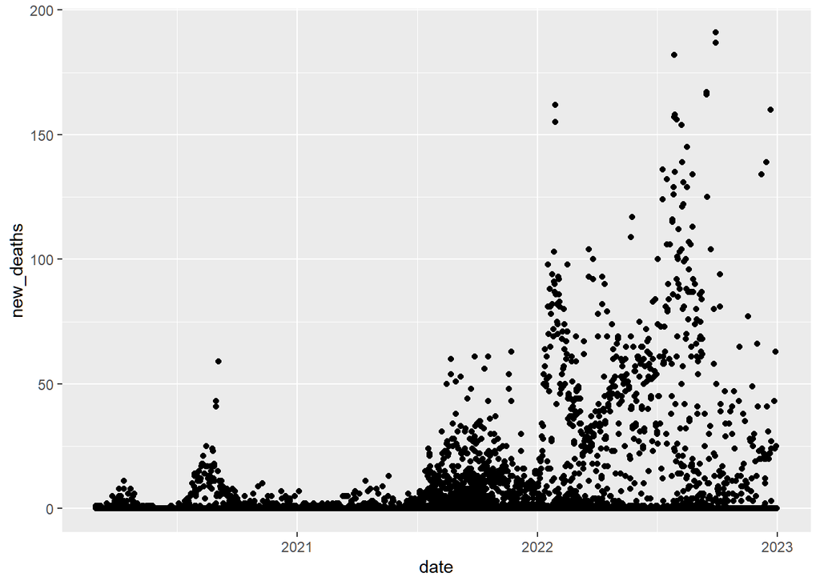

```r
ggplot(data = oc_start, aes(x = date, y =new_deaths)) + geom_point()
```

```r
#ggplot(data = oc_start, aes(x = date, y =hosp_patients)) + geom_point()
```

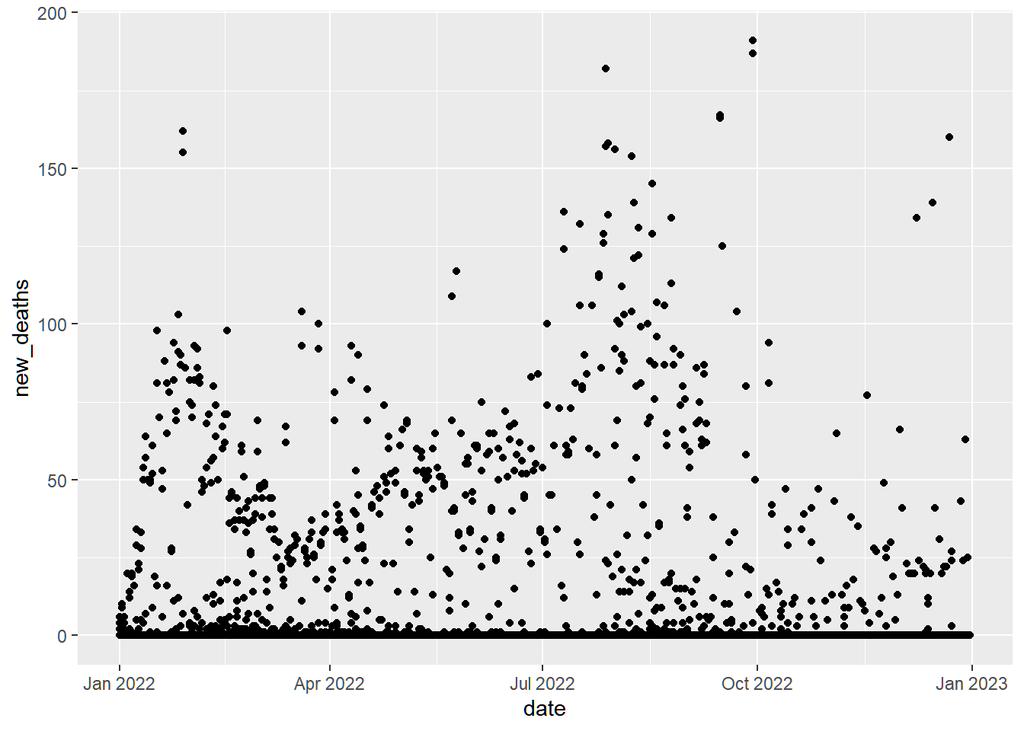

```r
oc_2022 <- oc_data[oc_data$date >= "2022-01-01" & oc_data$date <="2022-12-31", ]

ggplot(data = oc_2022, aes(x = date, y =new_deaths)) + geom_point()
```

```r
#ggplot(data = oc_2022, aes(x = date, y = hosp_patients)) + geom_point()
```

This second graph takes a closer look at the new death tolls in 2022. We can see that the new death tolls have some consistency throughout the year. However, there is an even bigger peak in the months of July through October. We then start to see this decline as we approach 2023. Through further research, Australia’s flu season is during our summer months which is their winter months. We can also see this trend in the first graph with peaks being in the middle of the year.

As seen from the first graph there was a peak in the winter months of 2021; however, the COVID-19 death tolls did not decrease, they continued to increase. There was a new peak in January and then there was another peak in August. I believe the cause of the continuation of new COVID-19 deaths was due restrictions being lifted for COVID-19. Our winter months would be considered Australia’s summer months, so this leaves room for more tourists and more action within the community now that restrictions are lifted. Now because of this surge in cases it has continued into flu season. Now because some of these deaths are of probable cause, there may be some outliers when it comes to the data. On a positive note, There seems to be a decline in new deaths involving COVID-19 as we begin to enter 2023. This shows that the surge may be a cause of lock down and is now leveling as Australia enters a busy season.